# Machine Learning Assignment

Roy Hulli

January 28, 2017

## Data Prep and Libraries

In this assignment the first step was to load the libraries we’ll need: caret, randomforest and corrplot , set the active directory, and load the training and testing data from PLM, is loaded and stored as matrix variables to enable manipulation.

```r
setwd("C:/Users/Azamat/Documents/R/Machine Learning 4")
TestA = read.csv("pml-testing.csv", na.strings = c("NA", "#DIV/0!", ""))
TrainA = read.csv("pml-training.csv",na.strings = c("NA", "#DIV/0!", ""))

library(caret)
library(randomForest)
```

```r
library(corrplot)
```

## Data Cleaning

Once loaded, the csv data itself contains some text fields, a date field, many NAs and columns that contain mainly blank values. Without removing these, the functions in R fail to perform, so some data cleaning is required. The first 6 columns are removed. And the NAs are removed.

```r
#remove non numeric columns
TrainA <- TrainA[, -(1:6)]

#clean NAs or mostly NA columns
NAs    <- sapply(TrainA, function(x) mean(is.na(x))) > 0.95
TrainA <- TrainA[, NAs==FALSE]
```

## Training and Testing

With a cleaned Train Dataset, it is then partitioned into 2 sets (train and test) to enable cross validation. At this point a correlation matrix can be plotted to see whether some variables have a high degree of correlation with the others

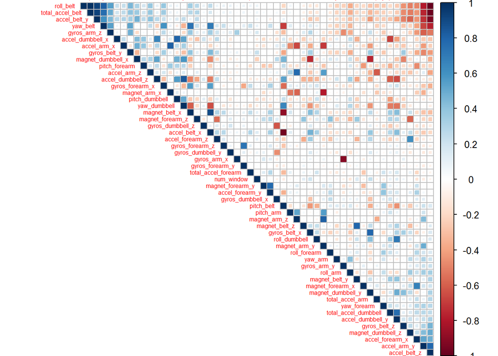

```r
#seperate train and test set
inTrain  <- createDataPartition(TrainA$classe, p=0.5, list=FALSE)
TrainSet <- TrainA[inTrain, ]
TestSet  <- TrainA[-inTrain, ]

#plot correlation ofvariables
corMatrix <- cor(TrainSet[, -54])
corrplot(corMatrix, order = "FPC", method = "square", type = "upper",
         add = FALSE, tl.cex = 0.5)
```

## Prediction Model

Based on the course lectures and online research regarding Kaggle competitions, random forest consistently proves to be a highly accurate, though computationally intensive, approach to building prediction models. Thus for this assignment, a random forest approach was used to build the model.

```r
#build a prediction model
# model fit
set.seed(150)
controlRF <- trainControl(method="cv", number=3, verboseIter=FALSE)
modFit <- train(classe ~ ., data=TrainSet, method="rf", trControl=controlRF, prox = TRUE)
modFit$finalModel
```

```
##
## Call:
##  randomForest(x = x, y = y, mtry = param$mtry, proximity = TRUE)
##                Type of random forest: classification
##                      Number of trees: 500
## No. of variables tried at each split: 27
##
##         OOB estimate of  error rate: 0.37%
## Confusion matrix:
##      A    B    C    D    E class.error
## A 2790    0    0    0    0 0.000000000
## B    5 1887    7    0    0 0.006319115
## C    0    7 1701    3    0 0.005844535
## D    0    0   12 1596    0 0.007462687
## E    0    0    0    2 1802 0.001108647
```

## Cross Validation

```r
#prediction - cross validation
predictRF <- predict(modFit, newdata=TestSet)
confMatRF <- confusionMatrix(predictRF, TestSet$classe)
confMatRF
```

```
## Confusion Matrix and Statistics
##
##           Reference
## Prediction    A    B    C    D    E
##          A 2789    6    0    0    0
##          B    0 1887    3    2    2
##          C    0    4 1708    5    0
##          D    0    1    0 1601    5
##          E    1    0    0    0 1796
##
## Overall Statistics
##
##                Accuracy : 0.997
##                  95% CI : (0.9958, 0.998)
##     No Information Rate : 0.2844
##     P-Value [Acc > NIR] : < 2.2e-16
##
##                   Kappa : 0.9963
##  Mcnemar's Test P-Value : NA
##
## Statistics by Class:
##
##                      Class: A Class: B Class: C Class: D Class: E
## Sensitivity            0.9996   0.9942   0.9982   0.9956   0.9961
## Specificity            0.9991   0.9991   0.9989   0.9993   0.9999
## Pos Pred Value         0.9979   0.9963   0.9948   0.9963   0.9994
## Neg Pred Value         0.9999   0.9986   0.9996   0.9991   0.9991
## Prevalence             0.2844   0.1935   0.1744   0.1639   0.1838
## Detection Rate         0.2843   0.1924   0.1741   0.1632   0.1831
## Detection Prevalence   0.2849   0.1931   0.1750   0.1638   0.1832
## Balanced Accuracy      0.9994   0.9967   0.9986   0.9975   0.9980
```

## Accuracy

Based on the results of the cross validation confusion matrix, which considered an equal quantity of new test data and training data, it is expected the out of sample error will be less than 1% for predictions based on new data.

## Predictions

Based on the random forest modelling, the predictions of the classe of exercises for the test data are found.

```r
#prediction
Testcases <- predict(modFit, newdata=TestA)
Testcases
```

```
##  [1] B A B A A E D B A A B C B A E E A B B B
## Levels: A B C D E
```